# Music Albums

Styliani Kalaitzaki

January 2024

```r
library(dplyr)
library(tidyr)
library(tidyverse)
library(ggplot2)
library(spData)
library(sf)
library(mapsf)
library(scales)
```

Read data:

```r
music_catalog <- read.csv("album.csv")
```

### Explore the data

```r
str(music_catalog)
```

```
## 'data.frame':    11461 obs. of  3 variables:
##  $ genre : chr  "Avant-Garde,Classical" "Avant-Garde,Classical" "Avant-Garde,Classical" "Avant-Garde,Classical,Electronic,Jazz" ...
##  $ artist: chr  "Kavina, Lydia" "Rockmore, Clara" "Rockmore, Clara" "Riley, Terry; Kronos Quartet" ...
##  $ album : chr  "(1999) Music From The Ether_ Original Works For Theremin" "(1987) The Art of the Theremin" "(2006) Clara Rockmore's Lost Theremin Album" "(1985) Cadenza on the Night Plain" ...
```

There are 11461 records and 3 variables:

- genre
- artist
- album

#### How many artists are there?

```r
music_catalog %>%
  distinct(artist) %>%
  summarise(artist_count = n())
```

```
##   artist_count
## 1         3692
```

#### Are there artists with multiple sets of genres?

```r
music_catalog %>%
  group_by(artist) %>%
  mutate(n = n_distinct(genre, artist)) %>%
  filter(n > 1)
```

```
## # A tibble: 16 × 4
## # Groups:   artist [2]
##    genre          artist       album                                          n
##    <chr>          <chr>        <chr>                                      <int>
##  1 Classical      Midori       (2005) ファースト                              2
##  2 Classical      Midori       (2007) セカンド                                2
##  3 Classical      Midori       (2007) 清水 (ep, JP)                           2
##  4 Classical      Midori       (2008) あらためまして、はじめまして、ミド…     2
##  5 Classical      Midori       (2008) ライブ!!                                2
##  6 Classical      Midori       (2010) shinsekai                               2
##  7 Jazz           Midori       (2005) ファースト                              2
##  8 Jazz           Midori       (2007) セカンド                                2
##  9 Jazz           Midori       (2007) 清水 (ep, JP)                           2
## 10 Jazz           Midori       (2008) あらためまして、はじめまして、ミド…     2
## 11 Jazz           Midori       (2008) ライブ!!                                2
## 12 Jazz           Midori       (2010) shinsekai                               2
## 13 Pop-Rock       James, Colin (2016) Blue Highways                           2
## 14 Pop-Rock       James, Colin (2018) Miles To Go                             2
## 15 Pop-Rock,Blues James, Colin (2016) Blue Highways                           2
## 16 Pop-Rock,Blues James, Colin (2018) Miles To Go                             2
```

Two artists, ‘Midori’ and ‘James Colin’ appear to have 2 sets of genres. Specifically, ‘Midori’ has albums devoted to two different genres, which might suggests he belongs in both. It is unclear which is the primary and which is the secondary. On the other hand, ‘James Colin’ on all 4 instances has Pop-Rock as a primary genre, but on two of them, Blues serves as a secondary genre. Unless there exists synonymy, it may be beneficial to preprocess the data by considering the removal of one instance.  
However, as the order of genres remains unclear in the first case, we will refrain from removing either of them. We will address the second case specifically below.

**Create a data frame for albums (genre, title, year)** by separating the ‘genre’ at the commas, keeping the first and droping the remainder. We extract the ‘year’ and ‘title’ from the ‘album’ column and remove the parentheses:

```r
albums <- separate(music_catalog, genre, into = "genre", sep = ",", extra = "drop") %>%
  # Extract the year and remove the parentheses
  mutate(
    year = str_remove_all(str_extract(album, "\\((\\d{4})\\)") , "\\(|\\)"),
    title = str_remove(str_extract(album, "\\)\\s*(.*)"), "\\)s*")
  ) %>%
  select(genre, title, year)
```

**Create two data frames for artists:**

artists_2_genres: (name, primary_genre, secondary_genre)  
artists_all_genres: (name, genre) [Contains duplicate rows of artists for different genres]

```r
artists_2_genres <- distinct(music_catalog[, c("genre","artist")]) %>%
  separate(genre, into = c("primary_genre","secondary_genre"), sep = ",", extra = "drop", fill = "right") %>%
  mutate(secondary_genre = coalesce(secondary_genre, primary_genre))


artists_all_genres <- distinct(music_catalog[, c("genre","artist")]) %>%
  separate_rows(genre, sep = ",")
```

We filter out the record of “James, Colin” with the same primary and secondary genre:

```r
artists_2_genres <- artists_2_genres %>%
  filter(!(artist == "James, Colin" & primary_genre == secondary_genre))
```

### 1a. What are the percentages of artists per primary genre?

Counting an artist only to their primary (first) genre.

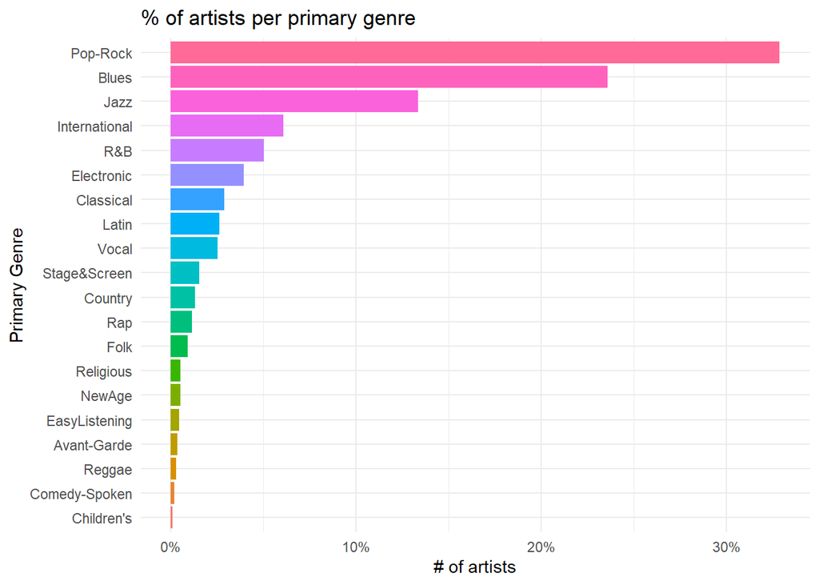

```r
artists_2_genres %>%
  count(primary_genre, sort = TRUE) %>%
  mutate(percentage = (n / sum(n)), primary_genre = fct_reorder(primary_genre, percentage)) %>%
  ggplot(aes(as.factor(primary_genre), percentage, fill = primary_genre)) +
  geom_col() +
  coord_flip() +
  scale_y_continuous(labels = percent_format()) +
  labs(title = "% of artists per primary genre", y = "# of artists", x = "Primary Genre") +
  theme_minimal() +
  theme(legend.position = "none")
```

### 1b. What are the percentages of artists per genre?

Counting an artist to all their genres.

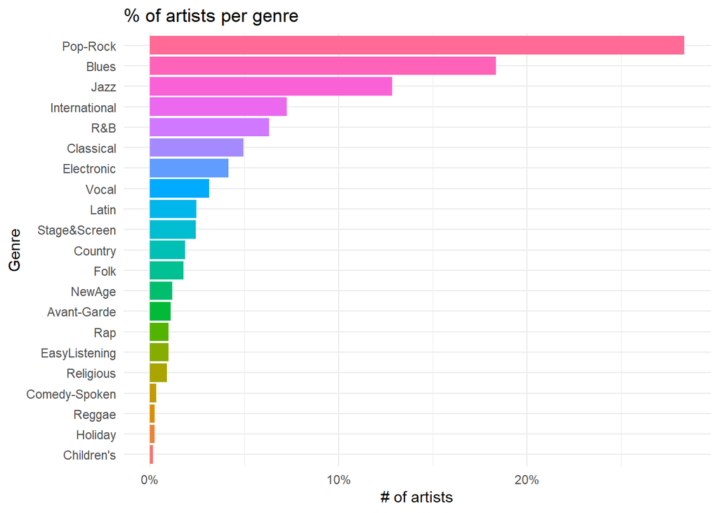

```r
artists_all_genres %>%
  # Count the number of artists per genre and sort in descending order
  count(genre, sort = TRUE) %>%
  # Calculate the percentage of artists per genre
  mutate(percentage = (n / sum(n)), genre = fct_reorder(genre, percentage)) %>%
  ggplot(aes(as.factor(genre), percentage, fill = genre)) +
  geom_col() +
  coord_flip() +
  # Format the y-axis labels as percentages
  scale_y_continuous(labels = percent_format()) +
  labs(title = "% of artists per genre", y = "# of artists", x = "Genre") +
  theme_minimal() +
  theme(legend.position = "none")
```

### 2. Album distribution per year

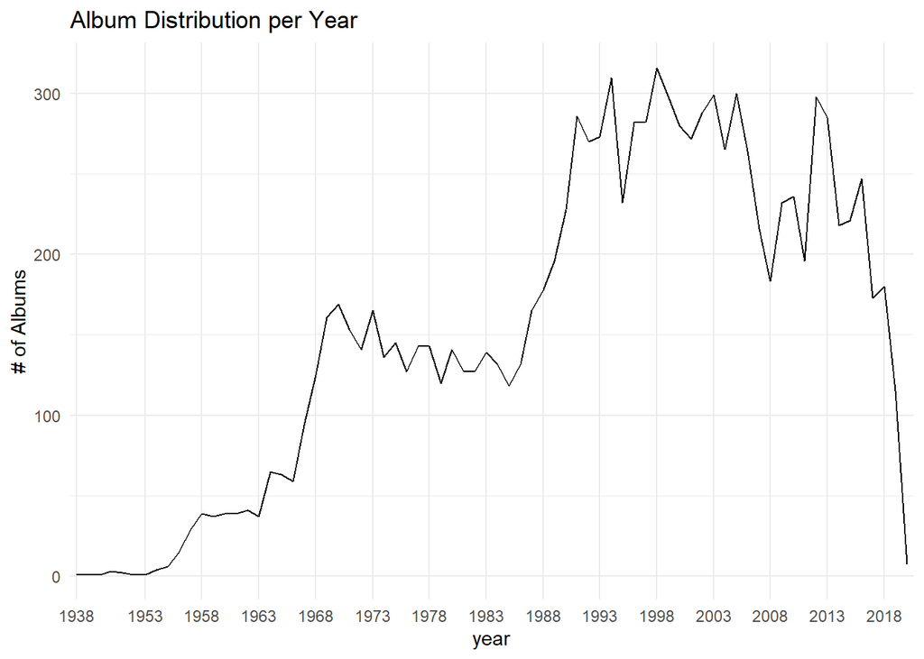

```r
albums %>%
  group_by(year) %>%
  # Create a new variable for the number of distinct albums per year
  mutate(n_albums_per_year = n_distinct(title)) %>%
  ggplot(aes(year, n_albums_per_year, group = 1)) +
  geom_line() +
  # Set discrete breaks on the x-axis
  scale_x_discrete(breaks = seq(min(albums$year), max(albums$year), by = 5)) +
  labs(title = "Album Distribution per Year", y = "# of Albums") +
  theme_minimal()
```

Album numbers experienced a significant surge in the late 80s and early 90s. Following some fluctuations, including a local minimum in 2008, they rebounded, reaching a peak by 2012. However, since then there is an evident decline.

### 3. Album distribution for the top 5 genres (primary) in time

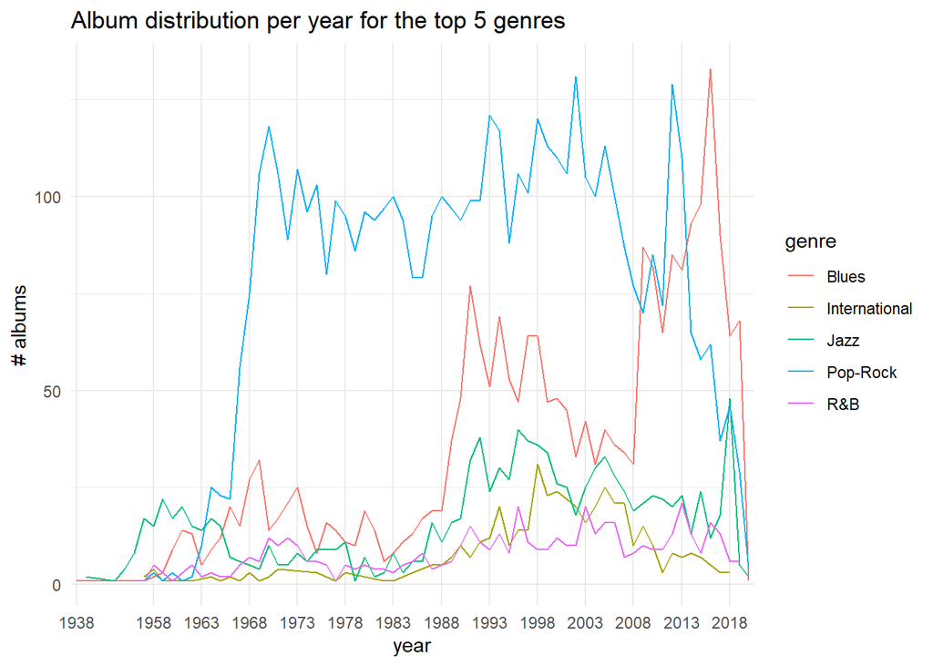

```r
top_5_genres <- albums %>%
  # Count the number of distinct albums per genre
  group_by(genre) %>%
  mutate(n_albums_per_genre = n_distinct(title)) %>%
  # Arrange the genres in descending order based on the number of albums
  arrange(desc(n_albums_per_genre)) %>%
  # Select the unique genres and keep the top 5 genres
  distinct(genre) %>%
  head(5)

albums %>%
  # Inner join the albums data with the top 5 genres based on the 'genre' column
  inner_join(top_5_genres, by = "genre") %>%
  select(names(albums)) %>%
  # Calculate the number of distinct albums per genre and year
  group_by(genre,year) %>%
  summarise(n_albums = n_distinct(title), .groups = "drop") %>%
  # Create a line plot
  ggplot(aes(year, n_albums, group = genre, color = genre)) +
  geom_line() +
  # Customize the x-axis breaks to show every 5 years
  scale_x_discrete(breaks = seq(min(albums$year), max(albums$year), by = 5)) +
  labs(title = "Album distribution per year for the top 5 genres", y = "# albums") +
  theme_minimal()
```

The top 5 genres are Pop-Rock, Blues, Jazz, International and R&B. Pop-Rock consistently dominates the chart, with Blues appearing to have started overtaking it relatively recently.

### 4. Exploring the correlation between artists’ primary and secondary genres.

```r
# Create a two-way table of primary and secondary genres from the artists_2_genres data
genre <- table(artists_2_genres$primary_genre, artists_2_genres$secondary_genre)
```

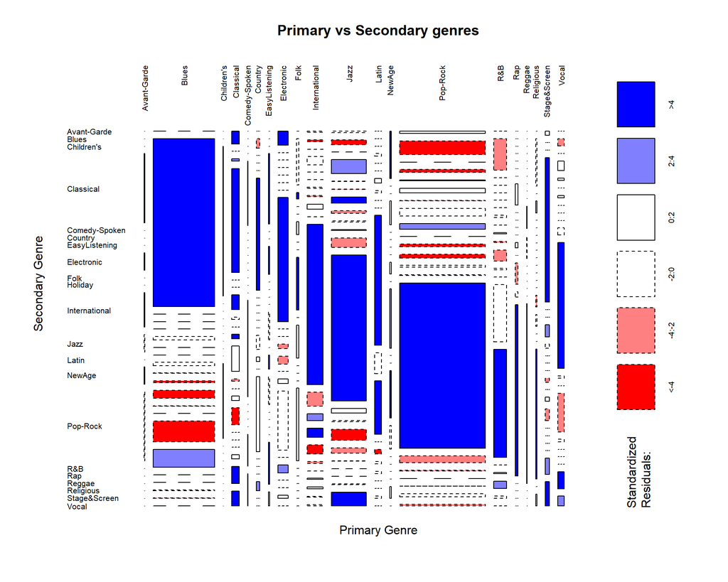

```r
mosaicplot(
     genre,
     shade = TRUE,
     las = 2,
     main = "Primary vs Secondary genres",
     xlab = "Primary Genre",
     ylab = "Secondary Genre"
)
```

Since the genres are too many (21) for readable visualization, we subset for the top 5.

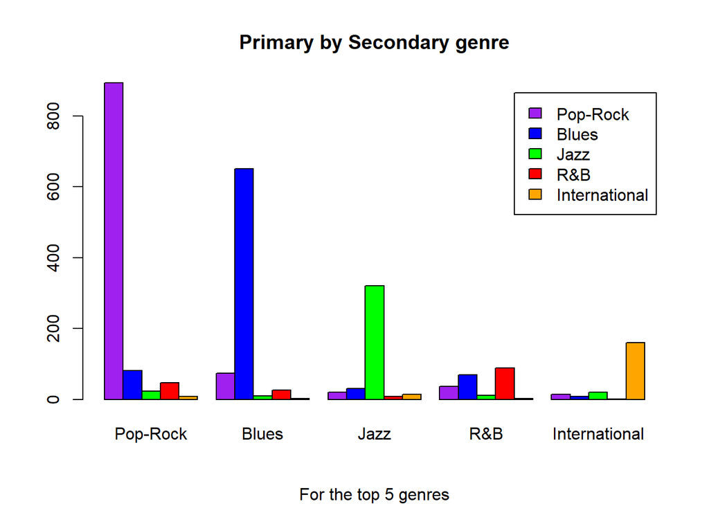

```r
barplot(
  genre[top_5_genres$genre, top_5_genres$genre],
  legend=T,
  beside=T,
  main= 'Primary by Secondary genre',
  sub = 'For the top 5 genres',
  col = c("purple", "blue", "green", "red", "orange")
)
```

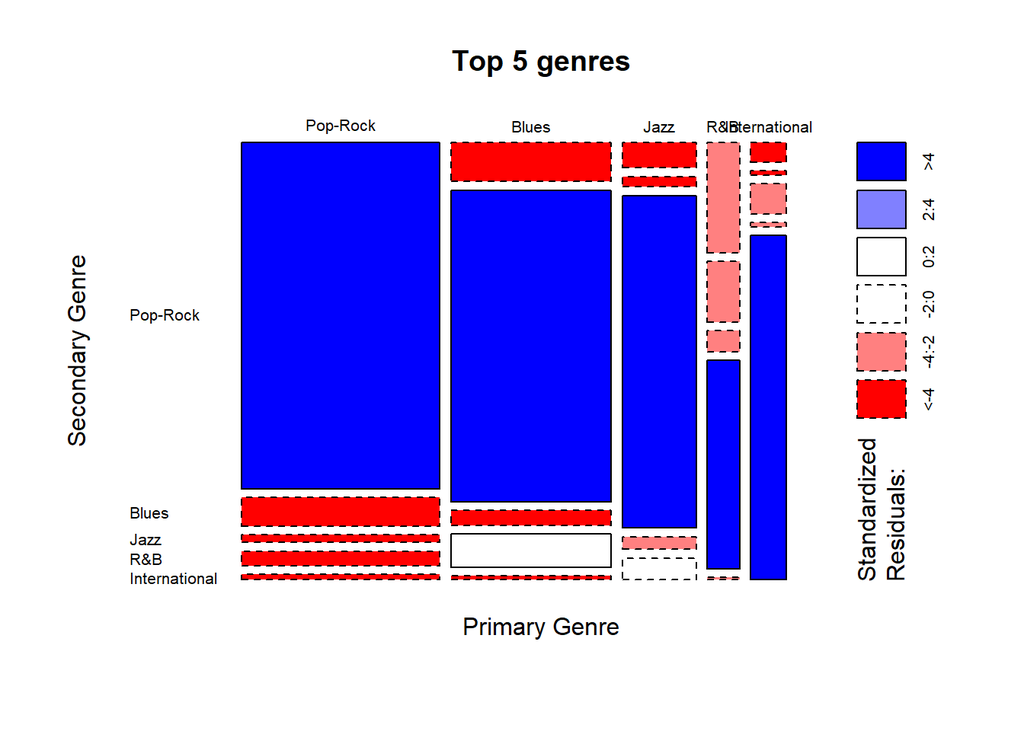

```r
mosaicplot(
  genre[top_5_genres$genre, top_5_genres$genre],
  shade = TRUE,
  las = 1,
  main = "Top 5 genres",
  xlab = "Primary Genre",
  ylab = "Secondary Genre"
)
```

It appears that most artists tend to stick to a single genre rather than experimenting with combinations, regardless of the genre. Pop-Rock is the most popular genre.

```r
prop.table(genre[top_5_genres$genre,top_5_genres$genre])
```

```
##
##                     Pop-Rock        Blues         Jazz          R&B
##   Pop-Rock      0.3404498666 0.0282119710 0.0076248570 0.0141059855
##   Blues         0.0308806710 0.2478078536 0.0118185284 0.0263057568
##   Jazz          0.0091498284 0.0038124285 0.1219977125 0.0045749142
##   R&B           0.0179184140 0.0099123141 0.0034311857 0.0339306138
##   International 0.0034311857 0.0007624857 0.0053373999 0.0007624857
##
##                 International
##   Pop-Rock       0.0053373999
##   Blues          0.0030499428
##   Jazz           0.0080060999
##   R&B            0.0003812429
##   International  0.0609988563
```

### 5. What countries appear in the album titles?

```r
# Extract country names the 'world' dataset
countries <- world$name_long

# Add '\\b' at the start of each country name so that it finds words that start with the country name (otherwise it matches 'woman' after the country Oman)
countries <- paste0("\\b", countries)

# Combine country names into a regex pattern separated by '|'
countries_str <- paste(countries, collapse="|")

# Use str_extract to match country names in the 'title' column
albums <- albums %>%
  mutate(country = str_extract(title, countries_str))
```

```r
world_albums <- albums %>%
  # Filter out albums with missing country information
  filter(!is.na(country)) %>%

  # Group albums by country and calculate the number of distinct titles
  group_by(country) %>%
  mutate(n_albums = n_distinct(title, year)) %>%

  # Merge with the 'world' dataset based on country names
  merge(world, by.x = "country", by.y = "name_long", all.y = TRUE) %>%

  # Select relevant columns for the final dataset
  select(country, n_albums, geom) %>%

  # Keep only distinct countries
  distinct(country, .keep_all = TRUE)
```

```r
mf_theme("iceberg")

mf_map(
  x = st_sf(world_albums),
  var = "n_albums",
  type = "choro",
  breaks = "geom",
  nbreaks = 5,
  pal = "Dark Mint",
  border = "white",
  lwd = 0.5,
  leg_pos = c(-180,20),
  leg_title = "# of albums",
  leg_no_data = "0",
  leg_val_rnd = 0
)


# layout
mf_layout(
  title = "Worldwide Album Distribution by Country",
  credits = ""
)
```

[figure not shown]

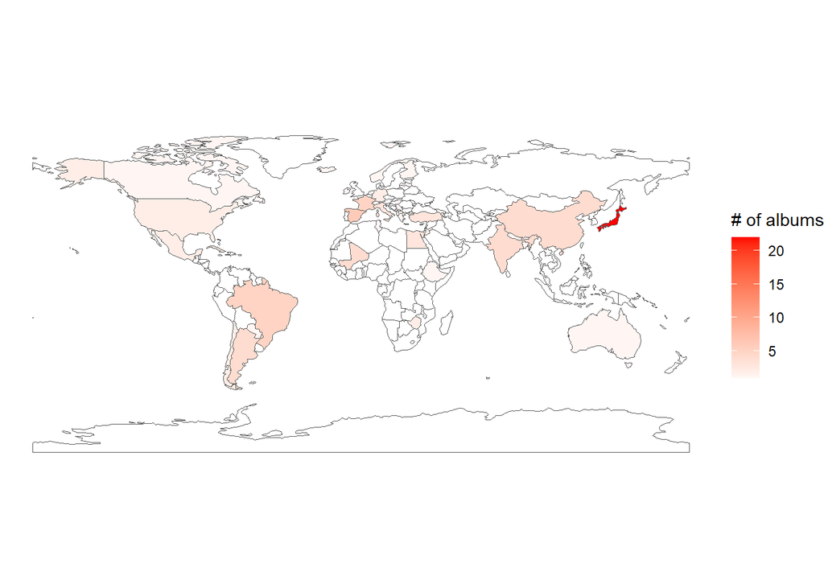

```r
st_sf(world_albums) %>%
  ggplot(aes(fill = n_albums)) +
  geom_sf() +
  coord_sf() +
  theme_void() +
  labs(fill = "# of albums") +
  scale_fill_gradient2(low = "pink", high= "red", na.value = "white")
```